# Advanced Modeling final project

Supervised Learning

Irene García

2025-06-18

## Introduction

This project aims to explore two key areas of predictive modeling: classification and advanced regression. Using customer behavior data, we first build models to predict churn risk, a well-defined classification task. We then shift to a regression problem, attempting to predict average transaction value. This contrast allows us to evaluate different modeling approaches, paying attention to both interpretation and predictive performance.

## Libraries

The first step is to load the libraries that we will use throughout the exercise.

```r
library(MASS)
library(Metrics)
library(dplyr)
library(tibble)
library(explore)
library(DataExplorer)
library(skimr)
library(stringr)
library(lubridate)
library(hms)
library(ggplot2)
library(ggeffects)
library(patchwork)
library(tidyr)
library(purrr)
library(GGally)
library(mice)
library(e1071)
library(caret)
library(nnet)
library(glmnet)
library(pROC)
library(naivebayes)
library(klaR)
library(rpart)
library(rpart.plot)
library(gbm)
library(pdp)
library(broom)
```

## Data load

```r
data <- read.csv("churn.csv")
```

This dataset focuses on customer churn and includes a series of demographic variables and historical consumer behavior data, providing insights into user characteristics and activity patterns that may influence retention.

# EDA and cleaning

```r
glimpse(data)
```

```
## Rows: 36,992
## Columns: 23
## $ age                          <int> 18, 32, 44, 37, 31, 13, 21, 42, 44, 45, 2…
## $ gender                       <chr> "F", "F", "F", "M", "F", "M", "M", "M", "…
## $ security_no                  <chr> "XW0DQ7H", "5K0N3X1", "1F2TCL3", "VJGJ33N…
## $ region_category              <chr> "Village", "City", "Town", "City", "City"…
## $ membership_category          <chr> "Platinum Membership", "Premium Membershi…
## $ joining_date                 <chr> "17-08-2017", "28-08-2017", "11-11-2016",…
## $ joined_through_referral      <chr> "No", "?", "Yes", "Yes", "No", "No", "Yes…
## $ referral_id                  <chr> "xxxxxxxx", "CID21329", "CID12313", "CID3…
## $ preferred_offer_types        <chr> "Gift Vouchers/Coupons", "Gift Vouchers/C…
## $ medium_of_operation          <chr> "?", "Desktop", "Desktop", "Desktop", "Sm…
## $ internet_option              <chr> "Wi-Fi", "Mobile_Data", "Wi-Fi", "Mobile_…
## $ last_visit_time              <chr> "16:08:02", "12:38:13", "22:53:21", "15:5…
## $ days_since_last_login        <int> 17, 16, 14, 11, 20, 23, 10, 19, 15, 10, 1…
## $ avg_time_spent               <dbl> 300.63, 306.34, 516.16, 53.27, 113.13, 43…
## $ avg_transaction_value        <dbl> 53005.25, 12838.38, 21027.00, 25239.56, 2…
## $ avg_frequency_login_days     <chr> "17", "10", "22", "6", "16", "24", "28", …
## $ points_in_wallet             <dbl> 781.7500, NA, 500.6900, 567.6600, 663.060…
## $ used_special_discount        <chr> "Yes", "Yes", "No", "No", "No", "Yes", "Y…
## $ offer_application_preference <chr> "Yes", "No", "Yes", "Yes", "Yes", "No", "…
## $ past_complaint               <chr> "No", "Yes", "Yes", "Yes", "Yes", "Yes", …
## $ complaint_status             <chr> "Not Applicable", "Solved", "Solved in Fo…
## $ feedback                     <chr> "Products always in Stock", "Quality Cust…
## $ churn_risk_score             <int> 0, 0, 1, 1, 1, 0, 0, 1, 0, 1, 1, 0, 1, 1,…
```

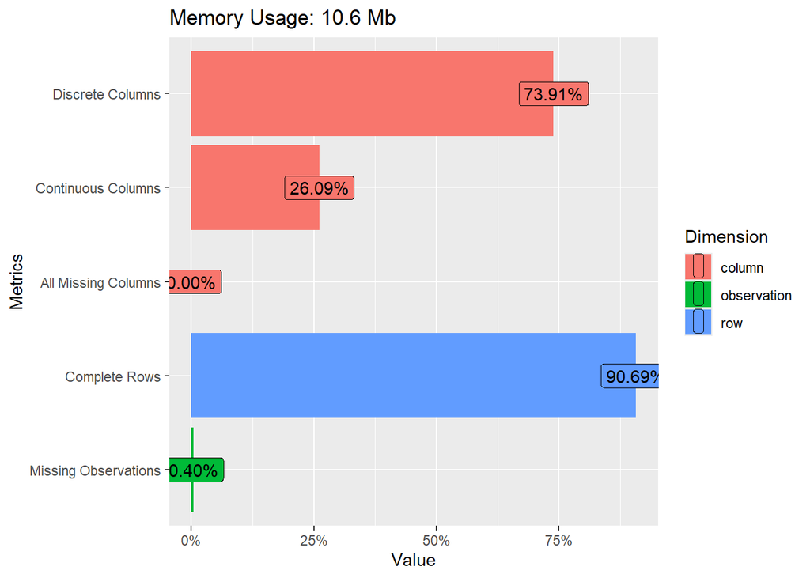

```r
plot_intro(data)
```

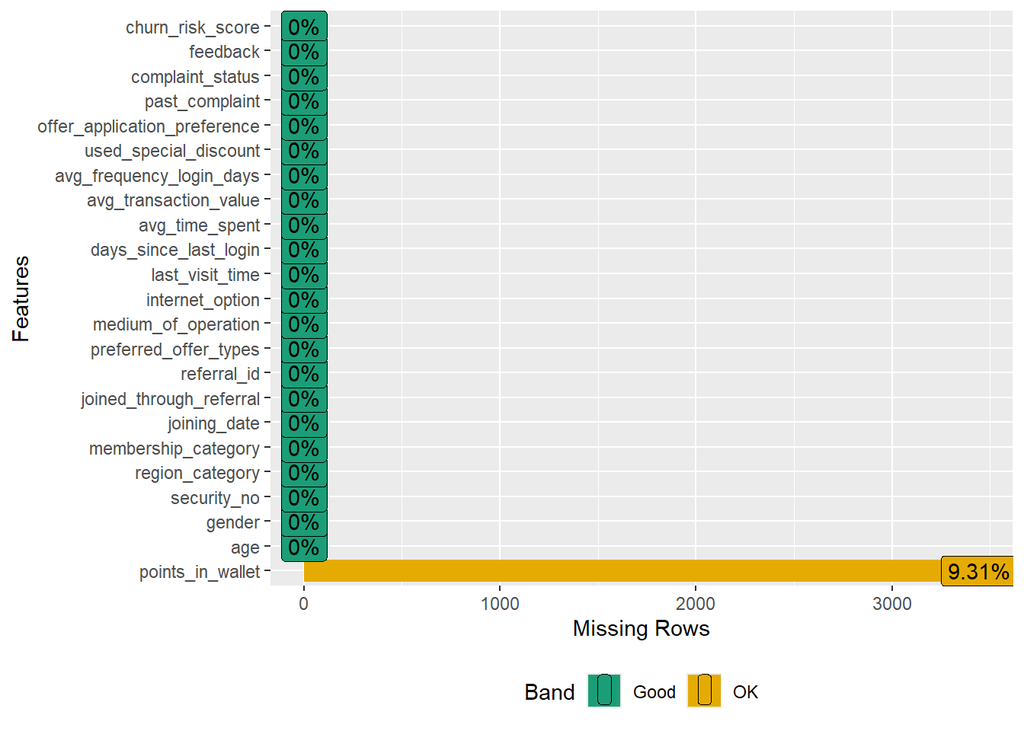

```r
plot_missing(data)
```

Our data consists of 6 numeric columns (3 of them are integer and the other 3 are continuous) and 17 categorical ones. We can anticipate that missing values might not be explicitly stored as NA, because only one variable appears to have missing values.

One of the first things I notice is that column names are already fairly clean. The following list contains a brief description of each variable in the dataset:

- customer_id: unique identification number of a customer
- age: age of a customer
- security_no: unique security number that is used to identify a person
- region_category: region that a customer belongs to
- membership_category: category of the membership that a customer is using
- joining_date: date when a customer became a member
- joined_through_referral: whether a customer joined using any referral code or ID
- referral_id: referral ID that the customer used for joining
- preferred_offer_types: type of offer that a customer prefers
- medium_of_operation: medium of operation that a customer uses for transactions
- internet_option: type of internet service a customer uses
- last_visit_time: last time a customer visited the website
- days_since_last_login: number of days since a customer last logged into the website
- avg_time_spent: average time spent by a customer on the website (likely in minutes)
- avg_transaction_value: average transaction value of a customer
- avg_frequency_login_days: number of times a customer has logged in to the website
- points_in_wallet: points awarded to a customer on each transaction
- used_special_discount: whether a customer uses special discounts offered
- offer_application_preference: whether a customer prefers offers
- past_complaint: whether a customer has raised any complaints
- complaint_status: whether the complaints raised by a customer were resolved
- feedback: feedback provided by a customer
- churn_risk_score: 0 - no churn, 1 - churn

### Handling missing data

There are two variables that have “?” for NAs: joined_through_referral and medium_of_operation. Another variable, referral_id, presents some rows with “xxxxxxxx”.

```r
# NAs as ?
data %>% summarise(across(everything(), ~ sum(. == "?", na.rm = TRUE)))
```

```
##   age gender security_no region_category membership_category joining_date
## 1   0      0           0               0                   0            0
##   joined_through_referral referral_id preferred_offer_types medium_of_operation
## 1                    5438           0                     0                5393
##   internet_option last_visit_time days_since_last_login avg_time_spent
## 1               0               0                     0              0
##   avg_transaction_value avg_frequency_login_days points_in_wallet
## 1                     0                        0                0
##   used_special_discount offer_application_preference past_complaint
## 1                     0                            0              0
##   complaint_status feedback churn_risk_score
## 1                0        0                0
```

```r
# xxxxx where Not Applicable
data %>%
  summarise(across(
    where(is.character),
    ~ sum(str_detect(.x, "^x+$"))))
```

```
##   gender security_no region_category membership_category joining_date
## 1      0           0               0                   0            0
##   joined_through_referral referral_id preferred_offer_types medium_of_operation
## 1                       0       17846                     0                   0
##   internet_option last_visit_time avg_frequency_login_days
## 1               0               0                        0
##   used_special_discount offer_application_preference past_complaint
## 1                     0                            0              0
##   complaint_status feedback
## 1                0        0
```

We can replace the first ones with NAs, whereas for referral_id, we can observe that those missing values correspond to the users for which join_through_referral is false, which makes perfect sense: if the user didn’t join through a referral, they cannot be linked to a specific referral ID. We can replace those rows with “Not Applicable” for clarity, but keeping in mind that an ID column is not useful for our analysis and will be dropped later on.

```r
data <- data %>%
  mutate(
    joined_through_referral = na_if(joined_through_referral, "?"),
    medium_of_operation = na_if(medium_of_operation, "?")
  )

data <- data %>%
  mutate(
    referral_id = ifelse(str_detect(referral_id, "^X+$"), "Not Applicable", referral_id)
  )
```

I also noticed that most of the NAs in joined_through_referral have a referral_id linked to them, which according to our logic means that they did in fact join through a referral, so we can manually “impute” those NAs as “Yes”.

```r
data <- data %>%
  mutate(
    joined_through_referral = case_when(
      is.na(joined_through_referral) & referral_id != "Not Applicable" ~ "Yes",
      TRUE ~ joined_through_referral
    )
  )
```

We can put this to test:

```r
data %>%
  filter(referral_id == "Not Applicable", joined_through_referral != "No") %>% count()
```

```
##   n
## 1 0
```

```r
data %>%
  filter(referral_id != "Not Applicable", joined_through_referral != "Yes") %>% count()
```

```
##       n
## 1 15839
```

Regarding the gender variable, there is an “unknown” category, which we can also convert to NA.

```r
table(data$gender)
```

```
##
##       F       M Unknown
##   18490   18443      59
```

```r
data <- data |>
  mutate(
    gender = na_if(gender, "Unknown")
  )
```

There are also variables stored in the wrong format, like avg_frequency_login_days, which should be numeric but is currently stored as character. The missing values in this column are stored as “Error”, so we replace them with explicit NAs.

```r
summary(data$avg_frequency_login_days)
```

```
##    Length     Class      Mode
##     36992 character character
```

```r
data |> filter(avg_frequency_login_days == "Error") |> count()
```

```
##      n
## 1 3522
```

```r
data <- data %>%
  mutate(
    avg_frequency_login_days = na_if(avg_frequency_login_days, "error"), # Replace "error" with NA
    avg_frequency_login_days = as.numeric(avg_frequency_login_days)      # Convert to numeric
  )
sum(is.na(data$avg_frequency_login_days))
```

```
## [1] 3522
```

Moving forward, NAs in region_category and preferred_offer_types are stored as empty strings, so we will also convert them to NAs.

```r
data <- data %>%
  mutate(region_category = na_if(region_category, ""),
         preferred_offer_types = na_if(preferred_offer_types, ""))
```

We can keep inspecting missing values in our numerical variables:

```r
numeric_vars <- data %>%
  select(where(is.numeric))

summary(numeric_vars)
```

```
##       age        days_since_last_login avg_time_spent    avg_transaction_value
##  Min.   :10.00   Min.   :-999.00       Min.   :-2814.1   Min.   :  800.5
##  1st Qu.:23.00   1st Qu.:   8.00       1st Qu.:   60.1   1st Qu.:14177.5
##  Median :37.00   Median :  12.00       Median :  161.8   Median :27554.5
##  Mean   :37.12   Mean   : -41.92       Mean   :  243.5   Mean   :29271.2
##  3rd Qu.:51.00   3rd Qu.:  16.00       3rd Qu.:  356.5   3rd Qu.:40855.1
##  Max.   :64.00   Max.   :  26.00       Max.   : 3235.6   Max.   :99914.1
##
##  avg_frequency_login_days points_in_wallet churn_risk_score
##  Min.   :-43.65           Min.   :-760.7   Min.   :0.000
##  1st Qu.:  9.00           1st Qu.: 616.1   1st Qu.:0.000
##  Median : 16.00           Median : 697.6   Median :1.000
##  Mean   : 15.98           Mean   : 686.9   Mean   :0.541
##  3rd Qu.: 23.00           3rd Qu.: 764.0   3rd Qu.:1.000
##  Max.   : 73.06           Max.   :2069.1   Max.   :1.000
##  NA's   :3522             NA's   :3443
```

We shouldn’t be seeing negative values for variables that reflect time. We may further inspect their distributions:

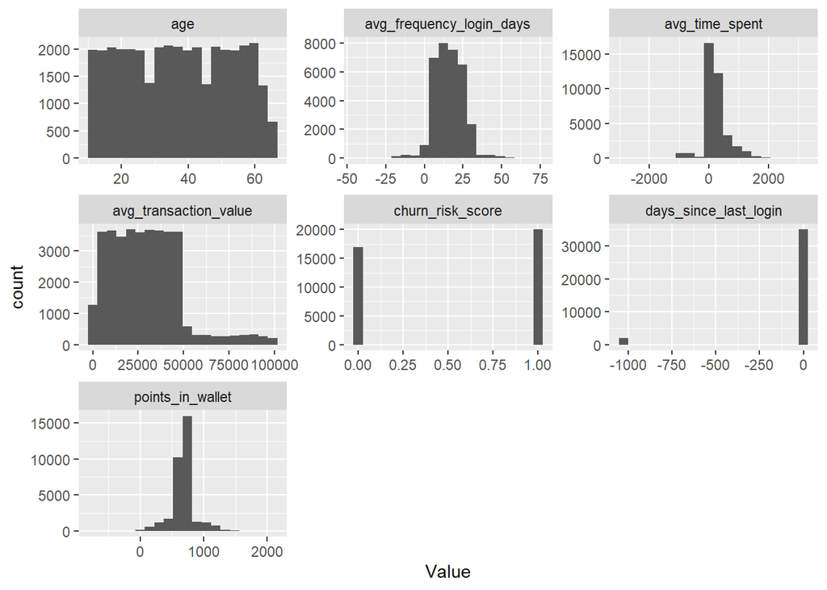

```r
numeric_vars |>
  gather(key = "Variable", value = "Value") |>
  ggplot(aes(x = Value)) +
  geom_histogram(bins = 20) +
  facet_wrap(~ Variable, scales = "free")
```

Age seems to be pretty homogeneously distributed across all users in the dataset. Users older than 60 become less likely.

Avg_transaction_value shows an odd distribution, where the vast majority of values lie below 50,000, where we see a sharp division, and a long tail extending to 100,000. However, the two groups appear to be quite uniform.

In the case of points_in_wallet, values are clustered tightly around 600-800, presenting little variation across the dataset.

If we look at days_since_last_login, the value of -999 is likely a recoded NA, since it’s the only negative value that the variable takes.

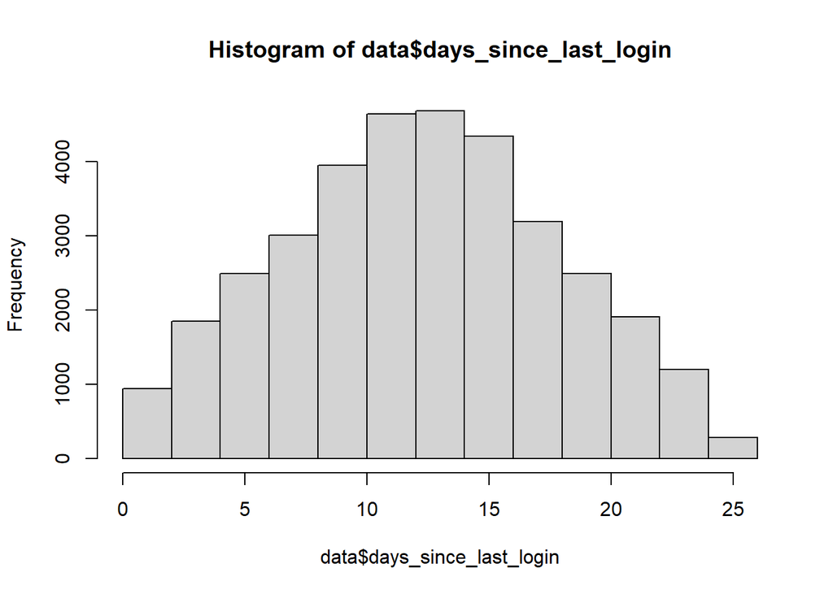

```r
data <- data |>
 mutate(
    days_since_last_login = na_if(days_since_last_login, -999))

hist(data$days_since_last_login)
```

After removing -999, the variable shows a close to normal distribution.

For avg_time_spent and avg_frequency_login_days, the negative values are not very frequent according to their distributions. Since we have no other way to interpret them, we might just treat them as errors and replace them with NAs. We will maintain the negative values in points_in_wallet, because they might be informative.

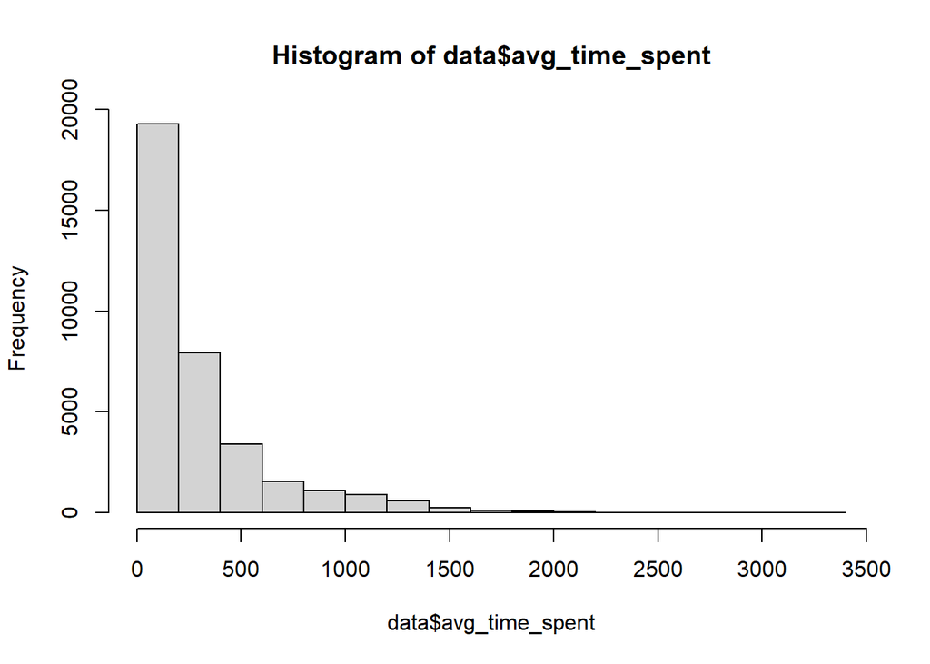

```r
data <- data %>%
  mutate(
    avg_time_spent = if_else(avg_time_spent < 0, NA_real_, avg_time_spent),
    avg_frequency_login_days = if_else(avg_frequency_login_days < 0, NA_real_, avg_frequency_login_days)
  )

hist(data$avg_time_spent)
```

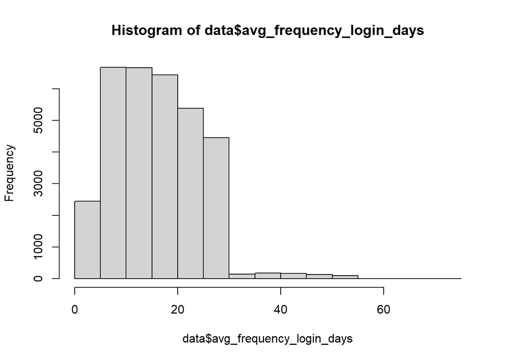

```r
hist(data$avg_frequency_login_days)
```

Both of these variables present positive skewness, indicating that values higher than 30 are much less likely than values lower. This variables indicates the number of days that users have logged into the app, but we don’t know in what time period.

### Categorical variables

```r
# Drop identifiers
data <- data |>
  select(-c(security_no, referral_id))

# Variables to exclude (not categorical)
exclude_vars <- c("joining_date", "last_visit_time")

# Convert character cols (except exclude_vars) to factors
data <- data %>%
  mutate(across(.cols = where(is.character) & !all_of(exclude_vars), as.factor))


data %>%
  select(where(is.factor)) %>%
  summarise(across(everything(), ~ paste(levels(.x), collapse = ", "))) %>%
  pivot_longer(cols = everything(),
               names_to = "variable",
               values_to = "labels")
```

```
## # A tibble: 12 × 2
##    variable                     labels
##    <chr>                        <chr>
##  1 gender                       F, M
##  2 region_category              City, Town, Village
##  3 membership_category          Basic Membership, Gold Membership, No Membershi…
##  4 joined_through_referral      No, Yes
##  5 preferred_offer_types        Credit/Debit Card Offers, Gift Vouchers/Coupons…
##  6 medium_of_operation          Both, Desktop, Smartphone
##  7 internet_option              Fiber_Optic, Mobile_Data, Wi-Fi
##  8 used_special_discount        No, Yes
##  9 offer_application_preference No, Yes
## 10 past_complaint               No, Yes
## 11 complaint_status             No Information Available, Not Applicable, Solve…
## 12 feedback                     No reason specified, Poor Customer Service, Poo…
```

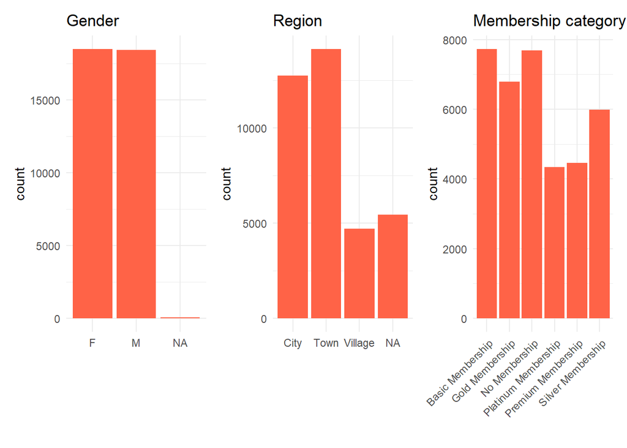

```r
p1 <- ggplot(data, aes(x = gender)) +
  geom_bar(fill = "tomato") +
  labs(title = "Gender", x = "", y = "count") +
  theme_minimal()
p2 <- ggplot(data, aes(x = region_category)) +
  geom_bar(fill = "tomato") +
  labs(title = "Region", x = "", y = "count") +
  theme_minimal()
p3 <- ggplot(data, aes(x = membership_category)) +
  geom_bar(fill = "tomato") +
  labs(title = "Membership category", x = "", y = "count") +
  theme_minimal() +
  theme(axis.text.x = element_text(angle = 45, hjust = 1))

p1 + p2 + p3
```

Gender is pretty balanced across the dataset. Regarding region, town is the most frequent category, followed by city, while village is much less common. Basic and No membership are the most common types of membership (probably the cheapest, if not free, options, with fewer user benefits), while platinum and premium (the most expensive ones, likely with greater advantages) are the less frequent ones.

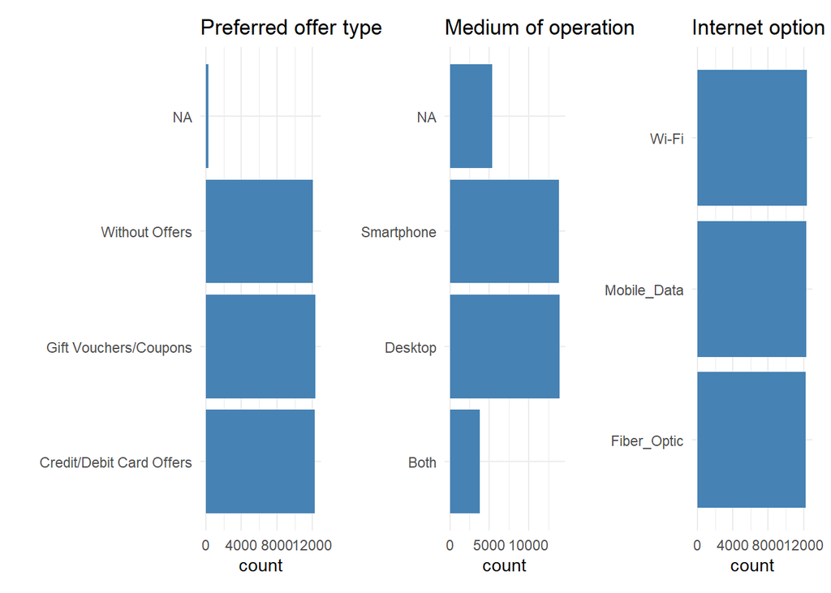

```r
p4 <- ggplot(data, aes(x = preferred_offer_types)) +
  geom_bar(fill = "steelblue") +
  labs(title = "Preferred offer type", x = "", y = "count") +
  theme_minimal() +
  coord_flip()
p5 <- ggplot(data, aes(x = medium_of_operation)) +
  geom_bar(fill = "steelblue") +
  labs(title = "Medium of operation", x = "", y = "count") +
  theme_minimal() +
  coord_flip()
p6 <- ggplot(data, aes(x = internet_option)) +
  geom_bar(fill = "steelblue") +
  labs(title = "Internet option", x = "", y = "count") +
  theme_minimal() +
  coord_flip()

p4 + p5 + p6
```

The preferred offer type is very balanced, as well as the internet option. Regarding medium of operation, users are more likely to use either their smartphones or their desktops, than both devices.

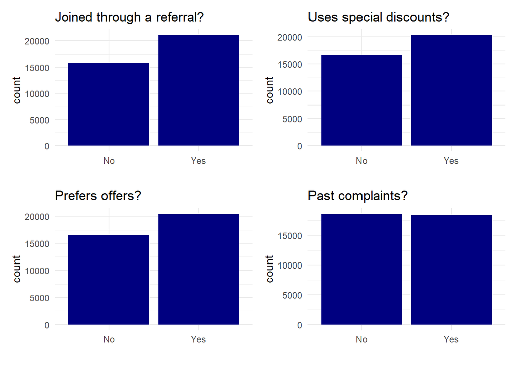

```r
p7 <- ggplot(data, aes(x = joined_through_referral)) +
  geom_bar(fill = "navy") +
  labs(title = "Joined through a referral?", x = "", y = "count") +
  theme_minimal()
p8 <- ggplot(data, aes(x = used_special_discount)) +
  geom_bar(fill = "navy") +
  labs(title = "Uses special discounts?", x = "", y = "count") +
  theme_minimal()
p9 <- ggplot(data, aes(x = offer_application_preference)) +
  geom_bar(fill = "navy") +
  labs(title = "Prefers offers?", x = "", y = "count") +
  theme_minimal()
p10 <- ggplot(data, aes(x = past_complaint)) +
  geom_bar(fill = "navy") +
  labs(title = "Past complaints?", x = "", y = "count") +
  theme_minimal()

p7 + p8 + p9 + p10
```

According to these plots, it’s more common to join to referral, to use special discounts, and to prefer offers than not. Approximately half of the users in the dataset have filed complaints in the past.

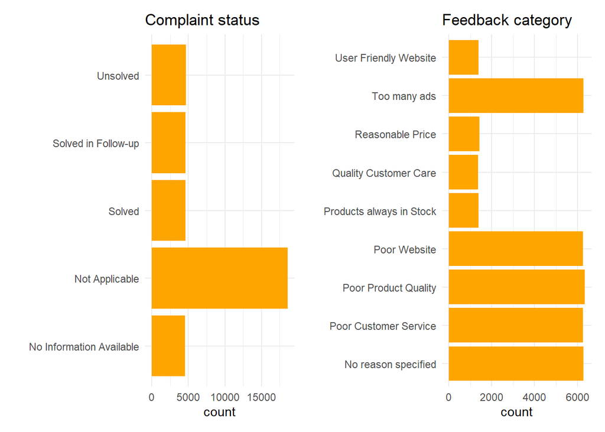

```r
p11 <- ggplot(data, aes(x = complaint_status)) +
  geom_bar(fill = "orange") +
  labs(title = "Complaint status", x = "", y = "count") +
  theme_minimal() +
  coord_flip()
p12 <- ggplot(data, aes(x = feedback)) +
  geom_bar(fill = "orange") +
  labs(title = "Feedback category", x = "", y = "count") +
  theme_minimal() +
  coord_flip()

p11 + p12
```

Regarding complaint status, the 4 options for actual complaints are fairly balanced, while Not Applicable likely refers to rows with no past complaints. Lastly, we observe that negative feedback comments are much more common than positive ones.

### Date and time variables

There are some date and time columns that we could convert, in order to get more useful variables for our analysis.

```r
data <- data %>%
  mutate(
    joining_date = dmy(joining_date),
    last_visit_time = as_hms(last_visit_time))
```

First,we convert the user’s joining date, extracting the year, the month, the day of the week and the number of days since the user joined:

```r
data <- data %>%
  mutate(
    joining_year = year(joining_date), # Extract year
    joining_month = month(joining_date), # Extract month number
    joining_weekday = wday(joining_date, label = TRUE, locale = "EN-us"), # Extract day of week
    days_since_joining = as.numeric(max(joining_date, na.rm = TRUE) - joining_date) # Days since joining
  )
```

Secondly, we convert the time of the user’s last visit to a factor variable indicating the period of the day:

```r
data <- data |>
  mutate(
    last_visit_hour = hour(last_visit_time),
    last_visit_period = factor(case_when(
      last_visit_hour >= 5  & last_visit_hour < 12 ~ "Morning",
      last_visit_hour >= 12 & last_visit_hour < 17 ~ "Afternoon",
      last_visit_hour >= 17 & last_visit_hour < 21 ~ "Evening",
      TRUE ~ "Night"
    ), levels = c("Morning", "Afternoon", "Evening", "Night"))
  )
data <- data |>
  mutate(joining_weekday = factor(joining_weekday, ordered = FALSE))
# convert to unordered
```

We can now check the distributions of these new variables:

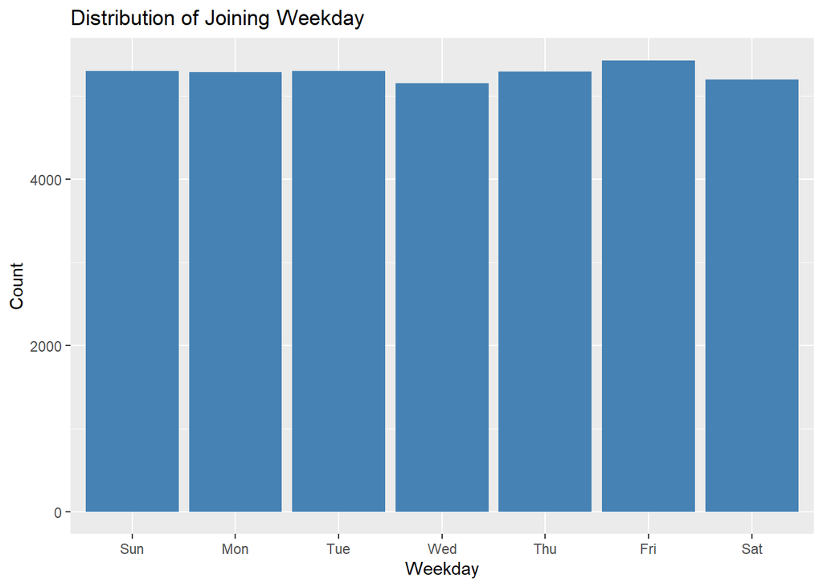

```r
ggplot(data, aes(x = joining_weekday)) +
  geom_bar(fill = "steelblue") +
  labs(title = "Distribution of Joining Weekday", x = "Weekday", y = "Count")
```

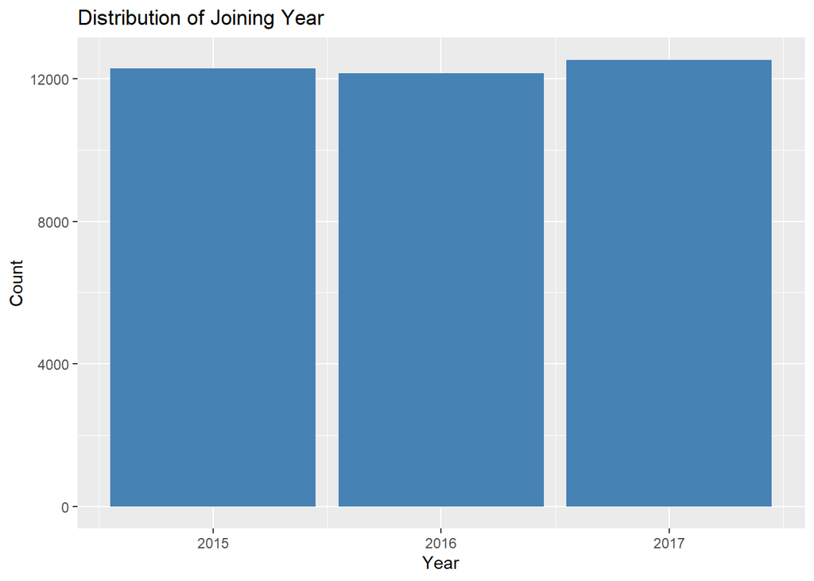

```r
ggplot(data, aes(x = joining_year)) +
  geom_bar(fill = "steelblue") +
  labs(title = "Distribution of Joining Year", x = "Year", y = "Count")
```

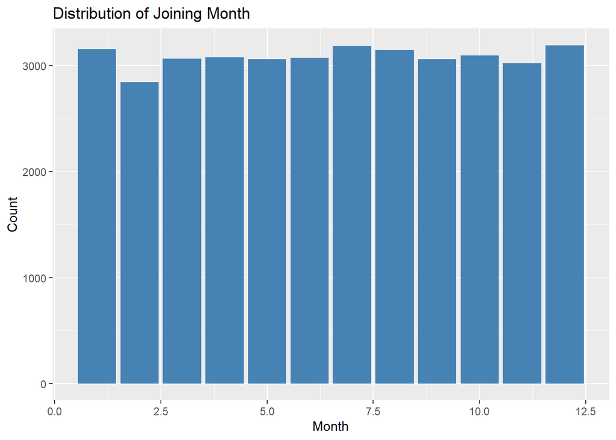

```r
ggplot(data, aes(x = joining_month)) +
  geom_bar(fill = "steelblue") +
  labs(title = "Distribution of Joining Month", x = "Month", y = "Count")
```

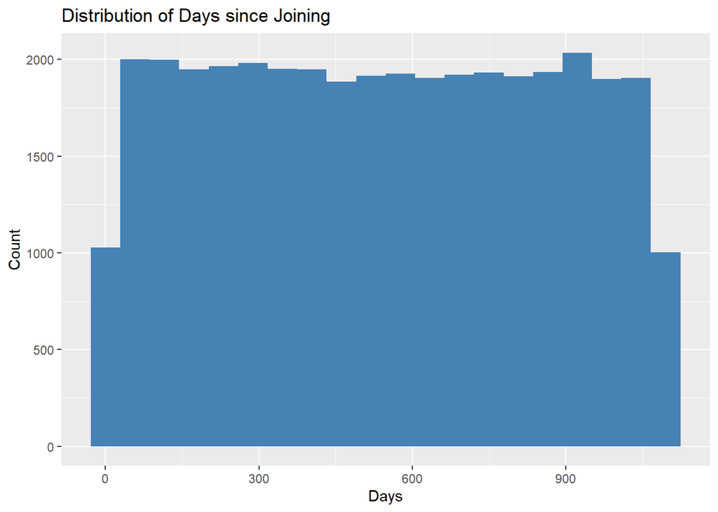

```r
ggplot(data, aes(x = days_since_joining)) +
  geom_histogram(fill = "steelblue", bins = 20) +
  labs(title = "Distribution of Days since Joining", x = "Days", y = "Count")
```

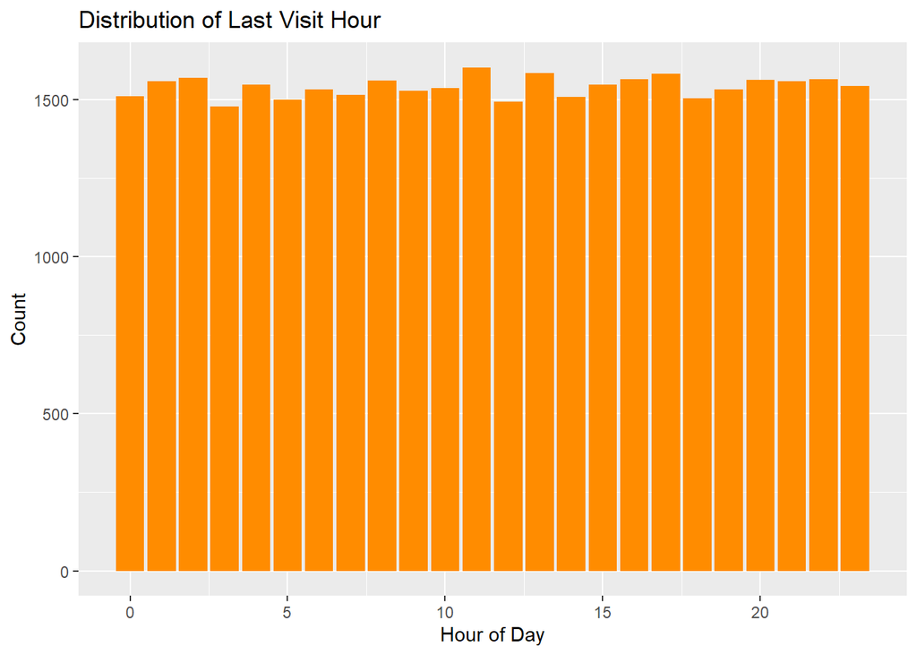

```r
ggplot(data, aes(x = last_visit_hour)) +
  geom_bar(fill = "darkorange") +
  labs(title = "Distribution of Last Visit Hour", x = "Hour of Day", y = "Count")
```

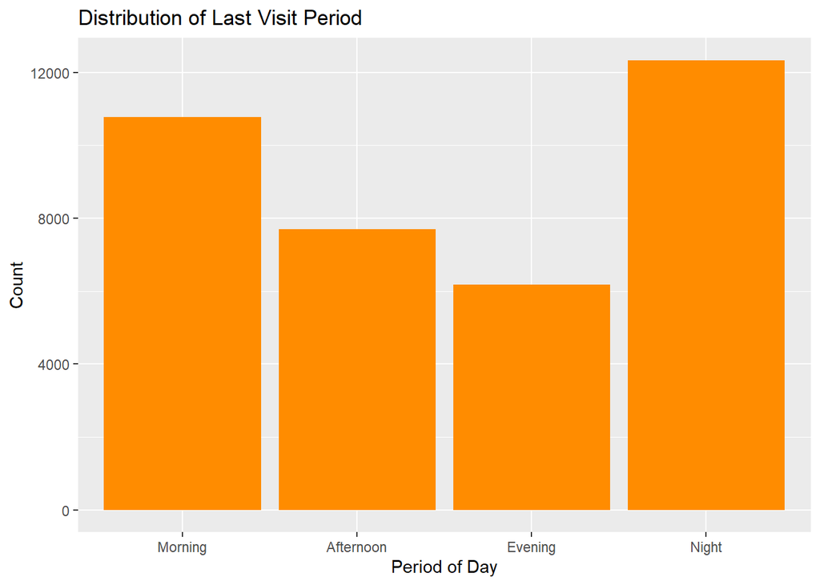

```r
ggplot(data, aes(x = last_visit_period)) +
  geom_bar(fill = "darkorange") +
  labs(title = "Distribution of Last Visit Period", x = "Period of Day", y = "Count")
```

Most of these new variables appear to be very uniform. Last visit period is the only one with a notable imbalance between categories, where night is the most frequent one.

We can now get rid of the less informative original variables, to avoid multicollinearity issues.

```r
data <- data %>%
  select(-joining_date, -last_visit_time)
```

After having converted our variables to the appropriate types and recoded NAs explicitly, we can repeat these tests:

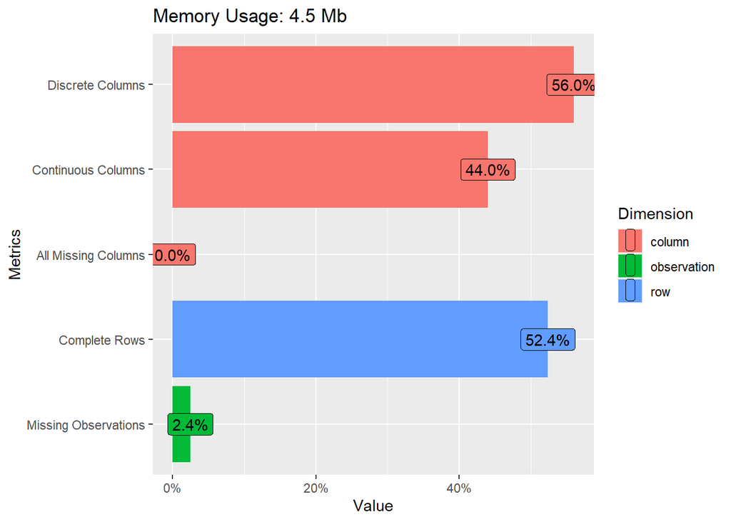

```r
plot_intro(data)
```

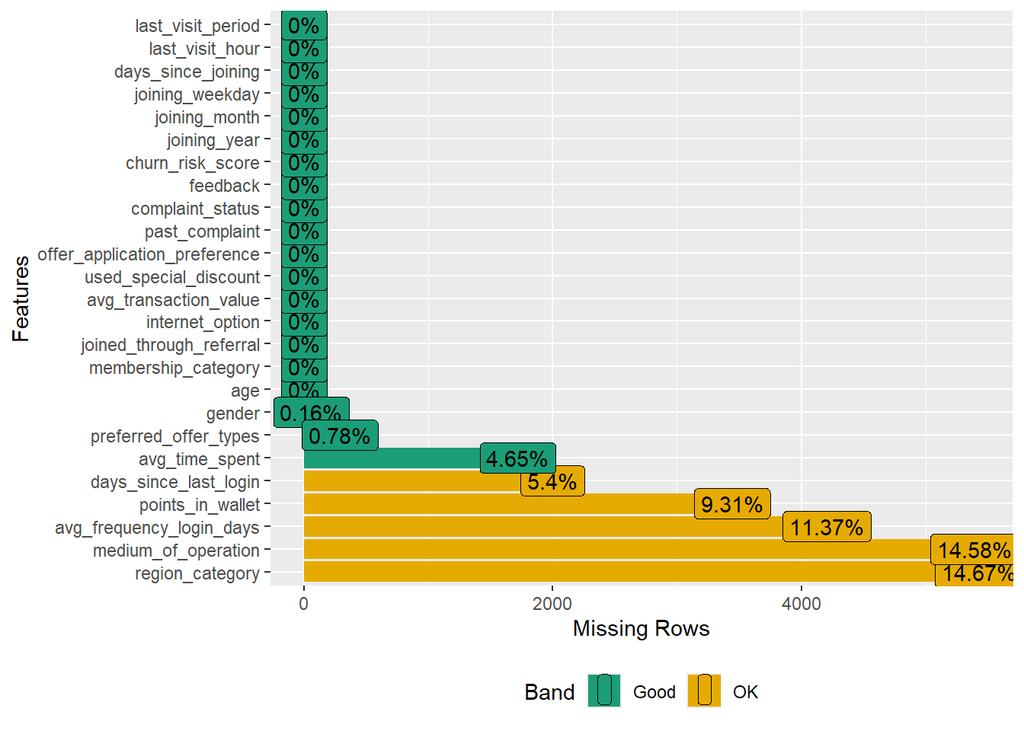

```r
plot_missing(data)
```

### Imputations

```r
set.seed(123)

m = 4 # number of multiple imputations

imputations <- mice(data, m = m, method = 'rf')
data_imp <- complete(imputations, action = m)
```

Finally, we check that imputations have worked:

```r
describe_tbl(data_imp)
```

```
## 36 992 (37k) observations with 25 variables
## 0 observations containing missings (NA)
## 0 variables containing missings (NA)
## 0 variables with no variance
```

Indeed, we now have 0 NAs in our dataset.

## Targets

For the supervised learning tasks, we first identified potential target variables for both classification and regression. For the classification task, we selected churn_risk_score as the categorical target, since it is the most natural choice for predicting customer retention. For the regression task, we considered several continuous variables that reflect customer behavior and value, such as points_in_wallet, days_since_last_login, avg_time_spent, and avg_transaction_value. After careful consideration, we chose avg_transaction_value as the regression target because it provides a meaningful measure of the customer’s average spending, which is crucial for business decision-making and revenue forecasting. This choice allows us to model and predict customer purchasing behavior effectively.

## Classification

In this section, we will apply probabilistic and machine learning methods for classification.

### Exploring the target: churn risk

Before moving on to modeling, we can explore the relationship of our binary outcome with the rest of the predictors in the dataset. First, we will check correlations between the numerical variables (including the target, which is currently stored as numeric, taking values 0 and 1).

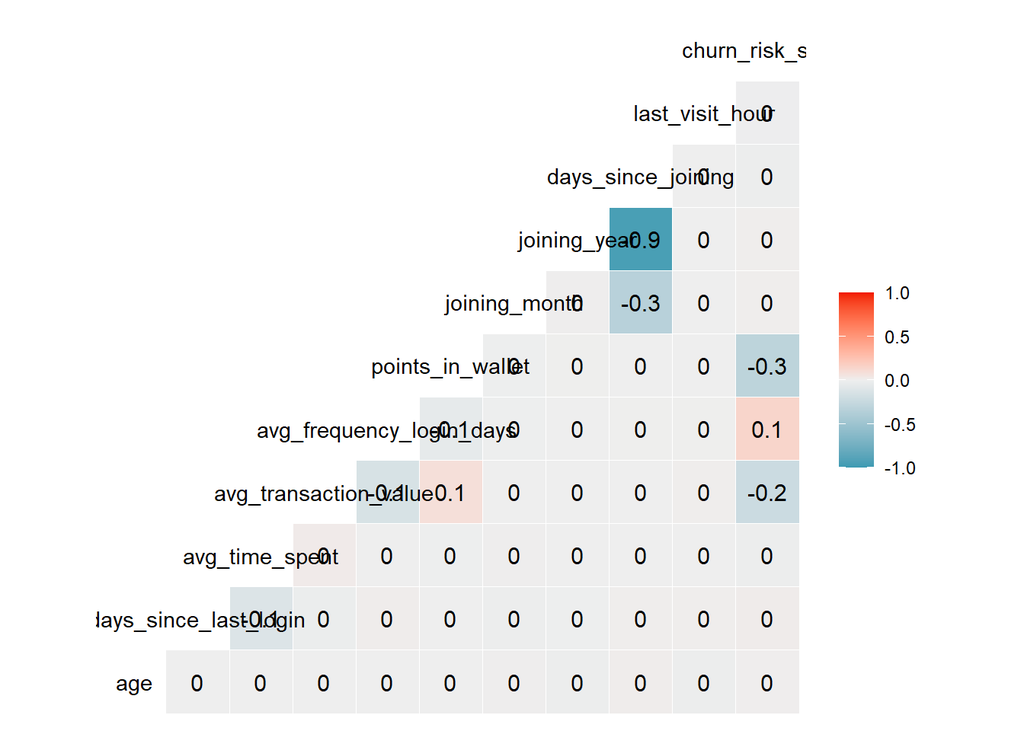

```r
# rewrite numeric variables
numeric_vars <- data_imp %>%
  select(
    age,
    days_since_last_login,
    avg_time_spent,
    avg_transaction_value,
    avg_frequency_login_days,
    points_in_wallet,
    joining_month,
    joining_year,
    days_since_joining,
    last_visit_hour,
    churn_risk_score
  )

ggcorr(numeric_vars, label = TRUE)
```

Since joining_year and days_since_joining are almost perfectly correlated, we will drop one of them.

```r
data_imp <- data_imp %>% select(-joining_year)
```

Now, we can plot the relationship between our target and the correlated variables:

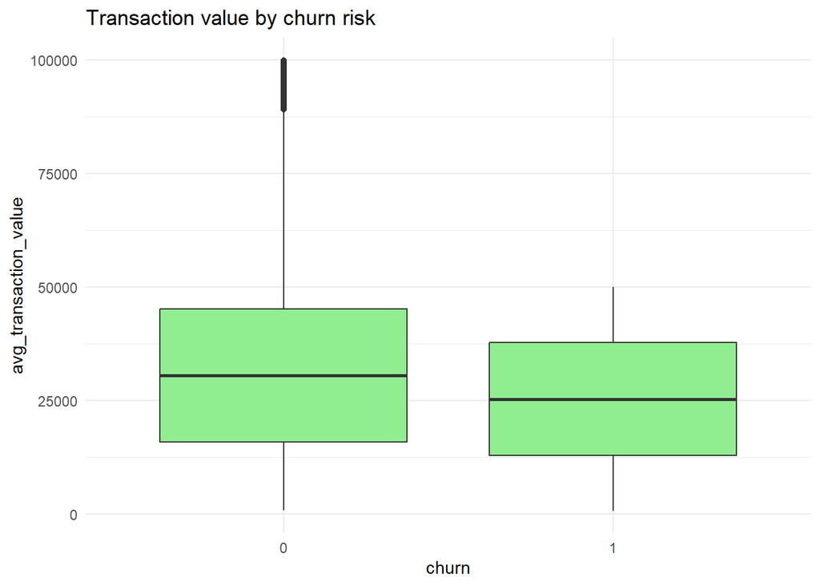

```r
# avg_transaction_value
ggplot(data_imp, aes(x = factor(churn_risk_score), y = avg_transaction_value)) +
  geom_boxplot(fill = "lightgreen") +
  labs(x = "churn", y = "avg_transaction_value",
       title = "Transaction value by churn risk") +
  theme_minimal()
```

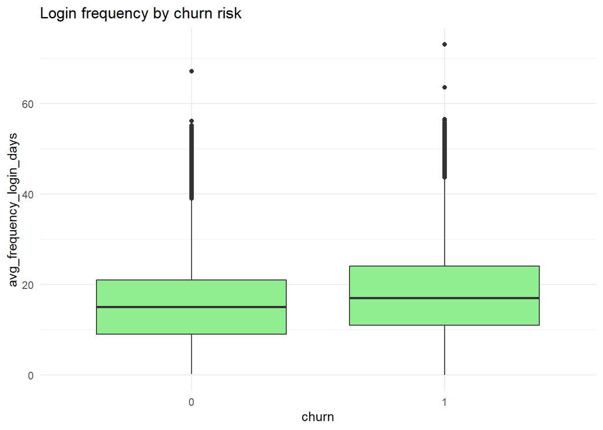

```r
# avg_frequency_login_days
ggplot(data_imp, aes(x = factor(churn_risk_score), y = avg_frequency_login_days)) +
  geom_boxplot(fill = "lightgreen") +
  labs(x = "churn", y = "avg_frequency_login_days",
       title = "Login frequency by churn risk") +
  theme_minimal()
```

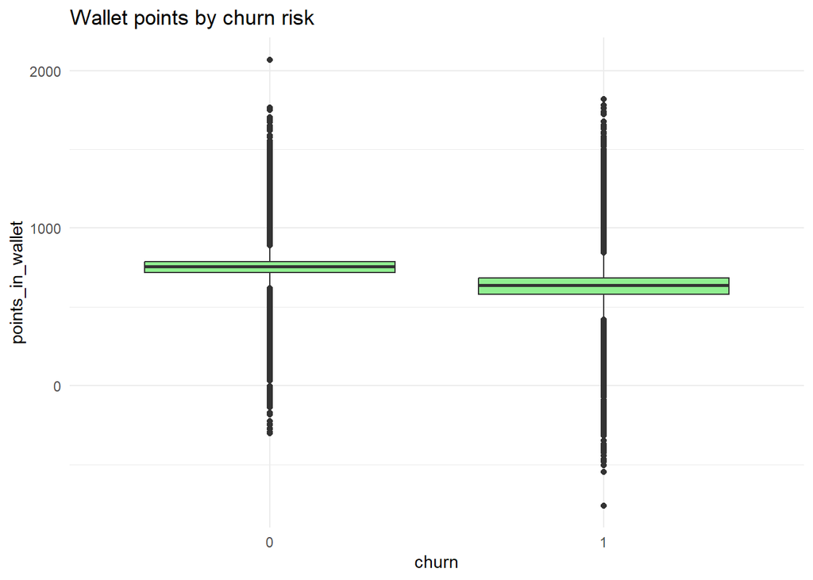

```r
# points_in_wallet
ggplot(data_imp, aes(x = factor(churn_risk_score), y = points_in_wallet)) +
  geom_boxplot(fill = "lightgreen") +
  labs(x = "churn", y = "points_in_wallet",
       title = "Wallet points by churn risk") +
  theme_minimal()
```

Average transaction value appears to be negatively associated with churn: high spenders are less likely to churn. The positive relationship between churn and average login days seems counterintuitive: non-churners login less frequently than churners, with a considerable number of outliers in both groups. Lastly, regarding wallet points, we see a negative relationship: users with more wallet points also seem less likely to churn. This variable contains a large number of outliers in both the lower and the higher ends.

Next, we can print the average churn risk score grouped by the different factor variables, to check how churn is distributed across categories. It’s worth noting that our categorical target variable seems fairly balanced across the whole dataset, with 54% users with churn risk score of 1.

```r
prop.table(table(data_imp$churn_risk_score))
```

```
##
##         0         1
## 0.4590182 0.5409818
```

```r
# Gender
data_imp %>%
    group_by(gender) %>%
    summarise(mean_churn = mean(churn_risk_score), count = n())
```

```
## # A tibble: 2 × 3
##   gender mean_churn count
##   <fct>       <dbl> <int>
## 1 F           0.543 18521
## 2 M           0.539 18471
```

```r
# Region
data_imp %>%
    group_by(region_category) %>%
    summarise(mean_churn = mean(churn_risk_score), count = n())
```

```
## # A tibble: 3 × 3
##   region_category mean_churn count
##   <fct>                <dbl> <int>
## 1 City                 0.548 14971
## 2 Town                 0.543 16712
## 3 Village              0.514  5309
```

```r
# Membership
data_imp %>%
    group_by(membership_category) %>%
    summarise(mean_churn = mean(churn_risk_score), count = n())
```

```
## # A tibble: 6 × 3
##   membership_category mean_churn count
##   <fct>                    <dbl> <int>
## 1 Basic Membership         0.968  7724
## 2 Gold Membership          0.370  6795
## 3 No Membership            0.971  7692
## 4 Platinum Membership      0      4338
## 5 Premium Membership       0      4455
## 6 Silver Membership        0.428  5988
```

```r
# Joined through referral
data_imp %>%
    group_by(joined_through_referral) %>%
    summarise(mean_churn = mean(churn_risk_score), count = n())
```

```
## # A tibble: 2 × 3
##   joined_through_referral mean_churn count
##   <fct>                        <dbl> <int>
## 1 No                           0.522 15839
## 2 Yes                          0.555 21153
```

```r
# Preferred offer types
data_imp %>%
    group_by(preferred_offer_types) %>%
    summarise(mean_churn = mean(churn_risk_score), count = n())
```

```
## # A tibble: 3 × 3
##   preferred_offer_types    mean_churn count
##   <fct>                         <dbl> <int>
## 1 Credit/Debit Card Offers      0.539 12363
## 2 Gift Vouchers/Coupons         0.516 12446
## 3 Without Offers                0.569 12183
```

```r
# Medium of operation
data_imp %>%
    group_by(medium_of_operation) %>%
    summarise(mean_churn = mean(churn_risk_score), count = n())
```

```
## # A tibble: 3 × 3
##   medium_of_operation mean_churn count
##   <fct>                    <dbl> <int>
## 1 Both                     0.521  4396
## 2 Desktop                  0.534 16292
## 3 Smartphone               0.554 16304
```

```r
# Internet option
data_imp %>%
    group_by(internet_option) %>%
    summarise(mean_churn = mean(churn_risk_score), count = n())
```

```
## # A tibble: 3 × 3
##   internet_option mean_churn count
##   <fct>                <dbl> <int>
## 1 Fiber_Optic          0.545 12236
## 2 Mobile_Data          0.542 12343
## 3 Wi-Fi                0.536 12413
```

```r
# Special discount use
data_imp %>%
    group_by(used_special_discount) %>%
    summarise(mean_churn = mean(churn_risk_score), count = n())
```

```
## # A tibble: 2 × 3
##   used_special_discount mean_churn count
##   <fct>                      <dbl> <int>
## 1 No                         0.547 16650
## 2 Yes                        0.536 20342
```

```r
# Offer application preference
data_imp %>%
    group_by(offer_application_preference) %>%
    summarise(mean_churn = mean(churn_risk_score), count = n())
```

```
## # A tibble: 2 × 3
##   offer_application_preference mean_churn count
##   <fct>                             <dbl> <int>
## 1 No                                0.551 16552
## 2 Yes                               0.533 20440
```

```r
# Past complaint
data_imp %>%
    group_by(past_complaint) %>%
    summarise(mean_churn = mean(churn_risk_score), count = n())
```

```
## # A tibble: 2 × 3
##   past_complaint mean_churn count
##   <fct>               <dbl> <int>
## 1 No                  0.537 18602
## 2 Yes                 0.545 18390
```

```r
# Complaint status
data_imp %>%
    group_by(complaint_status) %>%
    summarise(mean_churn = mean(churn_risk_score), count = n())
```

```
## # A tibble: 5 × 3
##   complaint_status         mean_churn count
##   <fct>                         <dbl> <int>
## 1 No Information Available      0.549  4550
## 2 Not Applicable                0.537 18602
## 3 Solved                        0.547  4619
## 4 Solved in Follow-up           0.549  4577
## 5 Unsolved                      0.536  4644
```

```r
# Feedback
data_imp %>%
    group_by(feedback) %>%
    summarise(mean_churn = mean(churn_risk_score), count = n())
```

```
## # A tibble: 9 × 3
##   feedback                 mean_churn count
##   <fct>                         <dbl> <int>
## 1 No reason specified           0.635  6290
## 2 Poor Customer Service         0.639  6252
## 3 Poor Product Quality          0.650  6350
## 4 Poor Website                  0.632  6271
## 5 Products always in Stock      0      1382
## 6 Quality Customer Care         0      1360
## 7 Reasonable Price              0      1417
## 8 Too many ads                  0.627  6279
## 9 User Friendly Website         0      1391
```

```r
# Joining weekday
data_imp %>%
    group_by(joining_weekday) %>%
    summarise(mean_churn = mean(churn_risk_score), count = n())
```

```
## # A tibble: 7 × 3
##   joining_weekday mean_churn count
##   <fct>                <dbl> <int>
## 1 Sun                  0.532  5307
## 2 Mon                  0.550  5290
## 3 Tue                  0.546  5307
## 4 Wed                  0.529  5157
## 5 Thu                  0.548  5296
## 6 Fri                  0.532  5432
## 7 Sat                  0.550  5203
```

```r
# Last visit period
data_imp %>%
    group_by(last_visit_period) %>%
    summarise(mean_churn = mean(churn_risk_score), count = n())
```

```
## # A tibble: 4 × 3
##   last_visit_period mean_churn count
##   <fct>                  <dbl> <int>
## 1 Morning                0.547 10778
## 2 Afternoon              0.538  7699
## 3 Evening                0.540  6181
## 4 Night                  0.539 12334
```

Churn risk seems to be pretty evenly distributed across most of our categorical variables, with the exception of membership category and feedback.

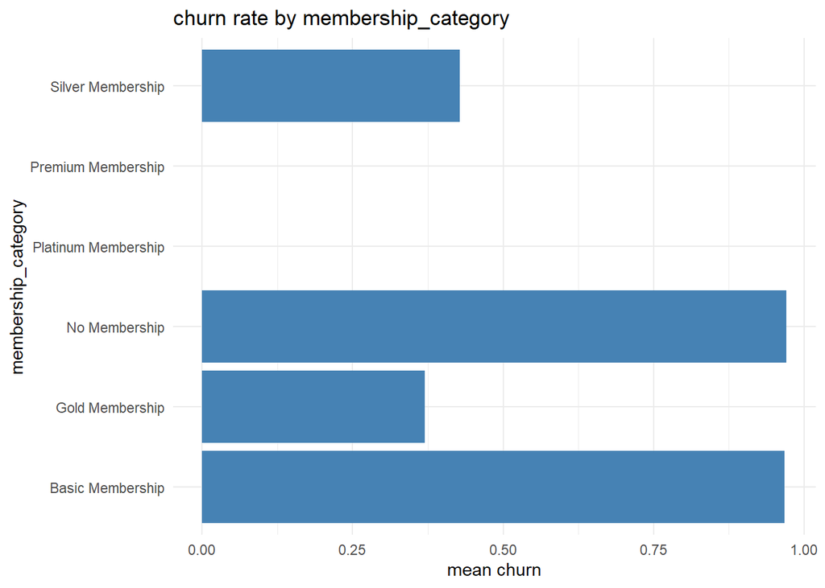

```r
# membership_category
ggplot(data_imp, aes(x = membership_category, y = churn_risk_score)) +
  stat_summary(fun = mean, geom = "bar", fill = "steelblue") +
  labs(title = "churn rate by membership_category", x = "membership_category", y = "mean churn") +
  theme_minimal() +
  coord_flip()
```

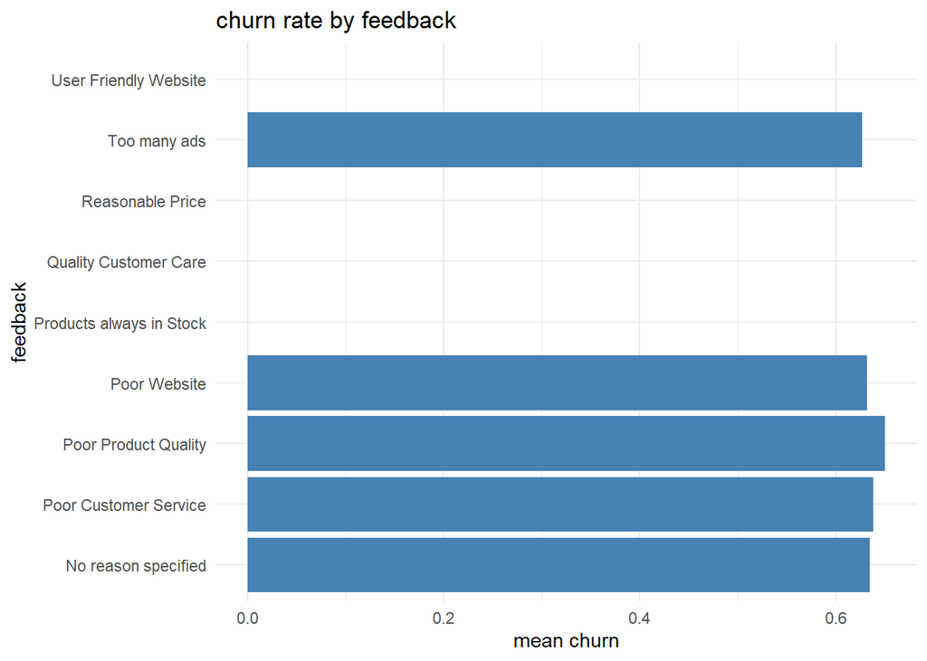

```r
# feedback
ggplot(data_imp, aes(x = feedback, y = churn_risk_score)) +
  stat_summary(fun = mean, geom = "bar", fill = "steelblue") +
  labs(title = "churn rate by feedback", x = "feedback", y = "mean churn") +
  theme_minimal() +
  coord_flip()
```

After these tests, we may convert our target variable to factor before modeling:

```r
data_imp <- data_imp |>
  mutate(
    churn_risk_score = factor(churn_risk_score,
                              levels = c("0", "1"),
                              labels = c("No", "Yes"))
  )
```

### Data split

We split the data stratifying by our target variable, with a proportion of 0.7 for training and 0.3 for testing.

```r
set.seed(123)
split <- createDataPartition(data_imp$churn_risk_score, p = 0.7, list = FALSE)
train <- data_imp[split, ]
test  <- data_imp[-split, ]

nrow(train)
```

```
## [1] 25895
```

```r
nrow(test)
```

```
## [1] 11097
```

The train set has 25,895 rows, and the test set has 11,097 rows.

### Benchmark model

We train a benchmark model to establish a baseline level of predictive performance, allowing us to evaluate whether more complex models provide meaningful improvements. The benchmark model always predicts the positive class (churn).

```r
benchmark_model <- glm(churn_risk_score ~ 1,
                      family = binomial(link ='logit'),
                      data = train)

benchmark_probs <- predict(benchmark_model,
                                 newdata = test,
                                 type = "response")

benchmark_pred <- ifelse(benchmark_probs > 0.5,
                         levels(train$churn_risk_score)[2],  # positive class
                         levels(train$churn_risk_score)[1])  # negative class

benchmark_pred <- factor(benchmark_pred,
                         levels = levels(train$churn_risk_score))

cm_benchmark <- confusionMatrix(benchmark_pred,
                test$churn_risk_score)
cm_benchmark
```

```
## Confusion Matrix and Statistics
##
##           Reference
## Prediction   No  Yes
##        No     0    0
##        Yes 5094 6003
##
##                Accuracy : 0.541
##                  95% CI : (0.5316, 0.5503)
##     No Information Rate : 0.541
##     P-Value [Acc > NIR] : 0.5039
##
##                   Kappa : 0
##
##  Mcnemar's Test P-Value : <2e-16
##
##             Sensitivity : 0.000
##             Specificity : 1.000
##          Pos Pred Value :   NaN
##          Neg Pred Value : 0.541
##              Prevalence : 0.459
##          Detection Rate : 0.000
##    Detection Prevalence : 0.000
##       Balanced Accuracy : 0.500
##
##        'Positive' Class : No
##
```

With a benchmark model we get a 54% accuracy, because there’s 54% of churners in our dataset. We expect to improve our predictions in the following lines.

### Probabilistic Learning

Since the target variable is binary and most predictors are categorical rather than purely numeric, multinomial logistic regression was selected due to its interpretability and suitability for categorical features. This approach serves as a reference point for evaluating more complex models. Although other alternatives, like Naive Bayes, were briefly considered, they were excluded from final modeling due to unstable performance and strong assumptions that did not align well with the structure of the dataset.

#### Multinomial Logistic Regression

First, we scale the numeric variables. We will use the mean and standard deviation of the train set to scale both the train and the test set, to prevent data leakage.

```r
# Identify numeric columns
num_cols <- sapply(train, is.numeric)

# Compute mean and sd from training set
means <- sapply(train[, num_cols], mean)
sds   <- sapply(train[, num_cols], sd)

# Scale training set
train_scaled <- train
train_scaled[, num_cols] <- sweep(train[, num_cols], 2, means, "-")
train_scaled[, num_cols] <- sweep(train_scaled[, num_cols], 2, sds, "/")

# Scale test set using training stats
test_scaled <- test
test_scaled[, num_cols] <- sweep(test[, num_cols], 2, means, "-")
test_scaled[, num_cols] <- sweep(test_scaled[, num_cols], 2, sds, "/")
```

Then, we move on to training the model.

```r
set.seed(123)
multinom_model <- multinom(churn_risk_score ~ ., data = train_scaled, trace = FALSE)
```

We use our model to predict churn on the test set.

```r
multinom_pred <- predict(multinom_model, newdata = test_scaled, type = "class")

cm_multinom <- confusionMatrix(multinom_pred, test$churn_risk_score, positive = "Yes")
cm_multinom
```

```
## Confusion Matrix and Statistics
##
##           Reference
## Prediction   No  Yes
##        No  4600  617
##        Yes  494 5386
##
##                Accuracy : 0.8999
##                  95% CI : (0.8941, 0.9054)
##     No Information Rate : 0.541
##     P-Value [Acc > NIR] : < 2.2e-16
##
##                   Kappa : 0.7988
##
##  Mcnemar's Test P-Value : 0.000252
##
##             Sensitivity : 0.8972
##             Specificity : 0.9030
##          Pos Pred Value : 0.9160
##          Neg Pred Value : 0.8817
##              Prevalence : 0.5410
##          Detection Rate : 0.4854
##    Detection Prevalence : 0.5299
##       Balanced Accuracy : 0.9001
##
##        'Positive' Class : Yes
##
```

The model performs very well, with high accuracy, strong sensitivity and specificity, and a high precision in identifying churners. It significantly outperforms a naive guess and shows balanced performance across classes, making it a reliable baseline for comparison with more complex models.

```r
# Predict probabilities for the positive class
probs_multinom <- predict(multinom_model, newdata = test_scaled, type = "prob")
roc_obj <- roc(response = test$churn_risk_score, predictor = probs_multinom)
# AUC value
auc_multinom <- auc(roc_obj)
auc_multinom
```

```
## Area under the curve: 0.9591
```

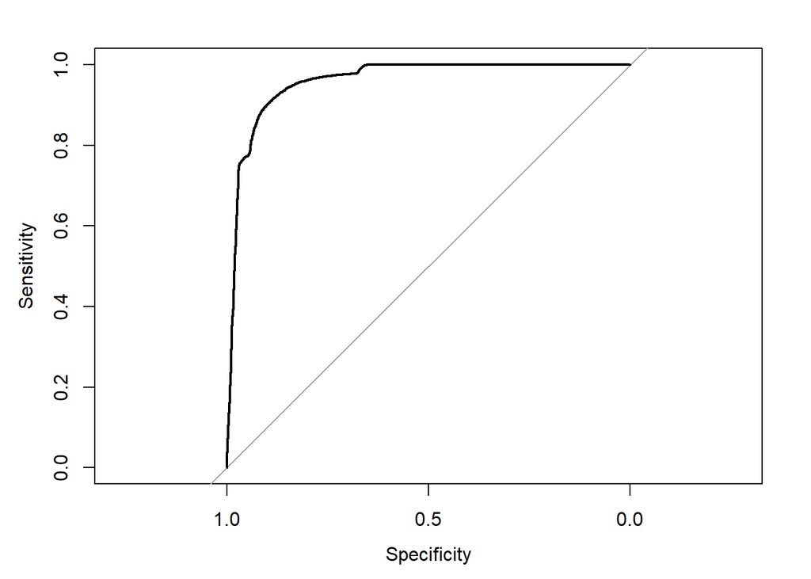

```r
# Plot the ROC curve
plot(roc_obj)
```

The AUC of the model is fairly high.

Next, we will extract and interpret the statistically significant predictors from the multinomial logistic regression model by filtering for variables with p-values below 0.05 and computing their odds ratios for easier interpretation.

```r
tidy(multinom_model) |>
  filter(p.value < 0.05) |>
  mutate(exp_estimate = exp(estimate)) |>
  select(term, estimate, exp_estimate, p.value) |>
  mutate(across(where(is.numeric), ~ round(.x, 3)))
```

```
## # A tibble: 11 × 4
##    term                                  estimate exp_estimate p.value
##    <chr>                                    <dbl>        <dbl>   <dbl>
##  1 (Intercept)                              2.27         9.70        0
##  2 membership_categoryGold Membership      -3.40         0.034       0
##  3 membership_categoryPremium Membership  -21.8          0           0
##  4 membership_categorySilver Membership    -3.38         0.034       0
##  5 points_in_wallet                        -0.466        0.628       0
##  6 past_complaintYes                        1.17         3.23        0
##  7 complaint_statusNot Applicable           1.1          3.00        0
##  8 feedbackProducts always in Stock       -15.2          0           0
##  9 feedbackQuality Customer Care          -17.3          0           0
## 10 feedbackReasonable Price               -18.4          0           0
## 11 feedbackUser Friendly Website          -14.9          0           0
```

We might now turn to variable importance:

```r
varImp(multinom_model) %>%
  arrange(desc(Overall))
```

```
##                                                 Overall
## membership_categoryPlatinum Membership     22.874133805
## membership_categoryPremium Membership      21.805910908
## feedbackReasonable Price                   18.407295443
## feedbackQuality Customer Care              17.285627999
## feedbackProducts always in Stock           15.243841099
## feedbackUser Friendly Website              14.935609626
## membership_categoryGold Membership          3.394707177
## membership_categorySilver Membership        3.383479089
## past_complaintYes                           1.172669789
## complaint_statusNot Applicable              1.099598819
## points_in_wallet                            0.465731819
## complaint_statusUnsolved                    0.155809439
## membership_categoryNo Membership            0.133744307
## feedbackPoor Product Quality                0.119242140
## joining_weekdayMon                          0.116261476
## complaint_statusSolved                      0.111911558
## internet_optionWi-Fi                        0.090211806
## last_visit_periodEvening                    0.085114986
## last_visit_periodNight                      0.082473401
## joining_weekdaySat                          0.080440924
## feedbackPoor Customer Service               0.059384167
## used_special_discountYes                    0.058711347
## region_categoryVillage                      0.057396701
## offer_application_preferenceYes             0.051779720
## joining_weekdayThu                          0.048990811
## joining_weekdayWed                          0.044765853
## last_visit_periodAfternoon                  0.044736380
## preferred_offer_typesGift Vouchers/Coupons  0.044597738
## joining_month                               0.042692259
## complaint_statusSolved in Follow-up         0.041644147
## joined_through_referralYes                  0.041559440
## medium_of_operationDesktop                  0.041334052
## preferred_offer_typesWithout Offers         0.041145127
## age                                         0.040597610
## joining_weekdayFri                          0.038518873
## feedbackToo many ads                        0.029458844
## medium_of_operationSmartphone               0.027836108
## days_since_last_login                       0.025582907
## days_since_joining                          0.023728309
## region_categoryTown                         0.022561588
## avg_frequency_login_days                    0.017485537
## joining_weekdayTue                          0.017265719
## internet_optionMobile_Data                  0.016445453
## last_visit_hour                             0.011443221
## avg_transaction_value                       0.011061517
## feedbackPoor Website                        0.006484145
## avg_time_spent                              0.005294351
## genderM                                     0.005220794
```

Membership tier is the most important overall predictor of churn behavior (particularly Premium and Platinum categories). Customer feedback variables are also critical.

We can further visualize these relationships:

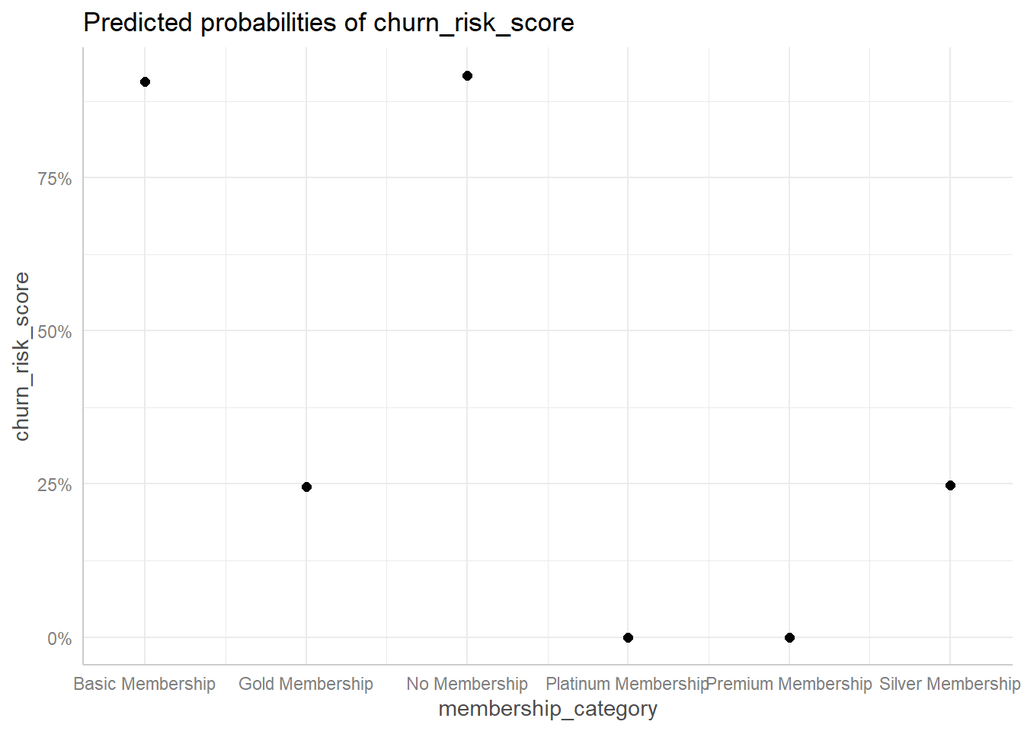

```r
ggpred <- ggpredict(multinom_model, terms = "membership_category")
plot(ggpred)
```

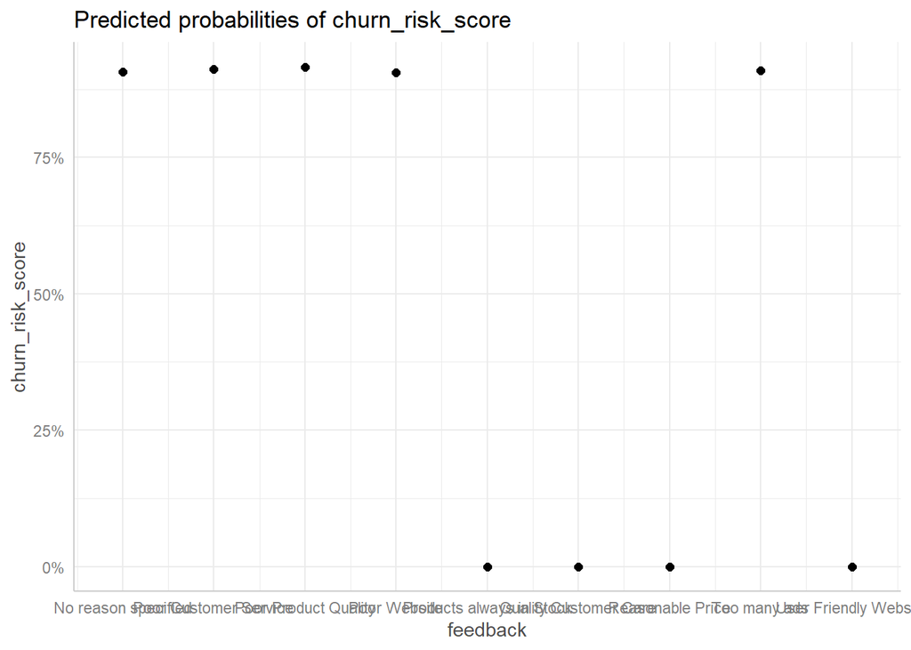

```r
ggpred <- ggpredict(multinom_model, terms = "feedback")
plot(ggpred)
```

```r
ggpred <- ggpredict(multinom_model, terms = "days_since_joining")
```

```
## Data were 'prettified'. Consider using `terms="days_since_joining
##   [all]"` to get smooth plots.
```

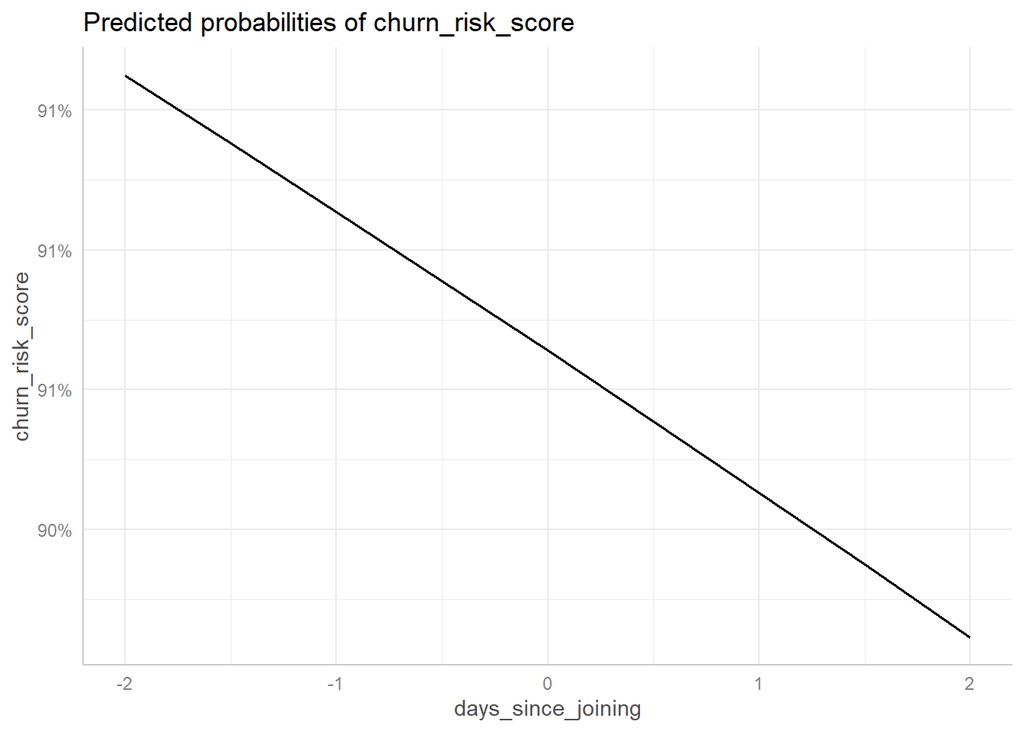

```r
plot(ggpred)
```

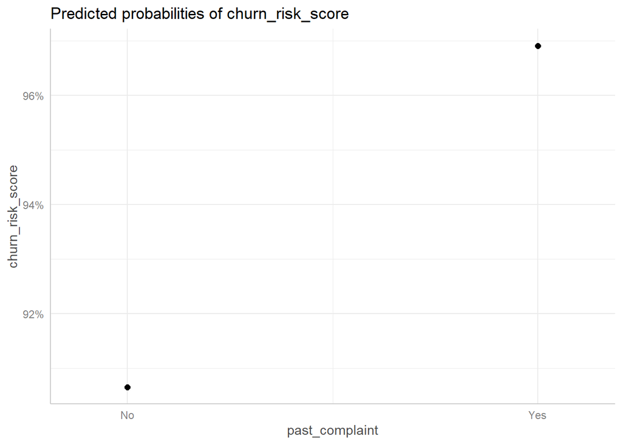

```r
ggpred <- ggpredict(multinom_model, terms = "past_complaint")
plot(ggpred)
```

Basic Membership and No Membership are associated with high churn risk.Platinum and Premium memberships are associated with a very low probability of churn. Negative feedback comments are consistently associated with very high probabilities of churn (as well as “No reason specified”), while positive ones are near zero.

#### Penalized regression

We can train a regularized multinomial logistic regression using the glmnet package with cross-validation to select the optimal penalty. Compared to the standard multinomial model, the regularized version achieves comparable predictive accuracy while reducing model complexity and stabilizing coefficient estimates.

```r
set.seed(123)
# Convert target to numeric class labels
y <- as.factor(train_scaled$churn_risk_score)
x <- model.matrix(churn_risk_score ~ . -1, data = train_scaled)  # one-hot encode

# Fit multinomial with cross-validated regularization
cv_model <- cv.glmnet(x, y, family = "multinomial", type.multinomial = "ungrouped", alpha = 1)

# Best lambda
cv_model$lambda.min
```

```
## [1] 4.629172e-05
```

```r
# Predict on test set
x_test <- model.matrix(churn_risk_score ~ . -1, data = test_scaled)
pred_class <- predict(cv_model, newx = x_test, s = "lambda.min", type = "class")
```

```r
cm_cv <- confusionMatrix(as.factor(pred_class), test$churn_risk_score)
cm_cv
```

```
## Confusion Matrix and Statistics
##
##           Reference
## Prediction   No  Yes
##        No  4611  615
##        Yes  483 5388
##
##                Accuracy : 0.9011
##                  95% CI : (0.8953, 0.9065)
##     No Information Rate : 0.541
##     P-Value [Acc > NIR] : < 2.2e-16
##
##                   Kappa : 0.8012
##
##  Mcnemar's Test P-Value : 7.705e-05
##
##             Sensitivity : 0.9052
##             Specificity : 0.8976
##          Pos Pred Value : 0.8823
##          Neg Pred Value : 0.9177
##              Prevalence : 0.4590
##          Detection Rate : 0.4155
##    Detection Prevalence : 0.4709
##       Balanced Accuracy : 0.9014
##
##        'Positive' Class : No
##
```

```r
probs_glmnet <- predict(cv_model, newx = x_test, s = "lambda.min", type = "response")[,,1]
roc_obj <- roc(response = test$churn_risk_score, predictor = probs_glmnet[, "Yes"])
auc_cv <- auc(roc_obj)
auc_cv
```

```
## Area under the curve: 0.9593
```

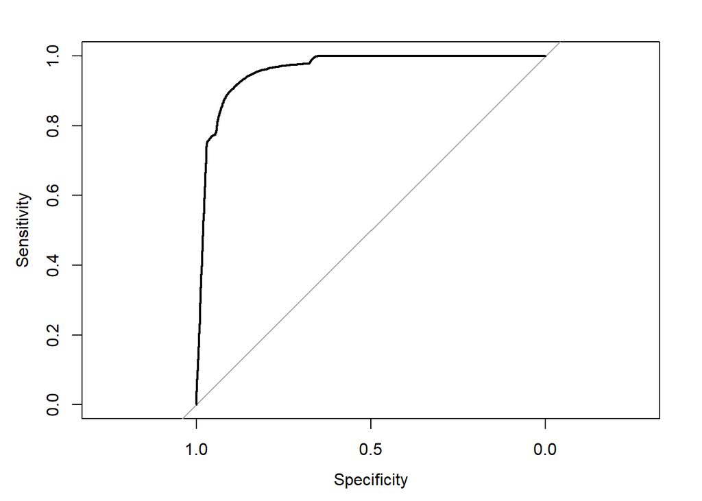

```r
plot(roc_obj)
```

```r
# Extract coefficients for the "Yes" class
coefs_glmnet <- coef(cv_model, s = "lambda.min")$Yes

# Convert to data frame and rename
coef_df <- as.matrix(coefs_glmnet)
coef_df <- data.frame(term = rownames(coef_df), estimate = coef_df[, 1])

# Tidy, filter, and format
coef_df %>%
  filter(term != "(Intercept)", estimate != 0) %>%
  mutate(
    exp_estimate = exp(estimate),
    across(where(is.numeric), ~ round(.x, 3))
  ) %>%
  arrange(desc(abs(estimate))) %>%
  select(-1)
```

```
##                                            estimate exp_estimate
## membership_categoryPlatinum Membership       -5.826        0.003
## membership_categoryPremium Membership        -5.760        0.003
## feedbackReasonable Price                     -3.529        0.029
## feedbackUser Friendly Website                -3.521        0.030
## feedbackQuality Customer Care                -3.507        0.030
## feedbackProducts always in Stock             -3.448        0.032
## membership_categoryGold Membership           -1.694        0.184
## membership_categorySilver Membership         -1.689        0.185
## points_in_wallet                             -0.232        0.793
## complaint_statusUnsolved                     -0.074        0.929
## membership_categoryNo Membership              0.068        1.070
## feedbackPoor Product Quality                  0.059        1.061
## joining_weekdayMon                            0.057        1.059
## complaint_statusSolved                       -0.052        0.950
## internet_optionWi-Fi                         -0.044        0.957
## last_visit_periodEvening                     -0.041        0.960
## joining_weekdaySat                            0.039        1.040
## last_visit_periodNight                       -0.039        0.961
## past_complaintYes                             0.033        1.033
## feedbackPoor Customer Service                 0.029        1.030
## region_categoryVillage                        0.027        1.028
## used_special_discountYes                     -0.026        0.975
## joining_weekdayThu                            0.024        1.024
## preferred_offer_typesGift Vouchers/Coupons   -0.022        0.978
## offer_application_preferenceYes              -0.022        0.978
## joining_weekdayWed                           -0.022        0.979
## joining_month                                -0.021        0.979
## age                                           0.020        1.020
## joined_through_referralYes                    0.020        1.020
## preferred_offer_typesWithout Offers           0.020        1.020
## last_visit_periodAfternoon                   -0.020        0.980
## joining_weekdayFri                           -0.019        0.982
## medium_of_operationDesktop                    0.018        1.018
## complaint_statusSolved in Follow-up          -0.017        0.984
## feedbackToo many ads                          0.014        1.014
## days_since_last_login                         0.012        1.013
## medium_of_operationSmartphone                 0.011        1.011
## days_since_joining                           -0.011        0.989
## region_categoryTown                           0.010        1.011
## avg_frequency_login_days                      0.009        1.009
## joining_weekdayTue                           -0.008        0.992
## internet_optionMobile_Data                   -0.007        0.993
## avg_transaction_value                        -0.006        0.994
## last_visit_hour                              -0.006        0.994
## feedbackPoor Website                         -0.003        0.997
## genderF                                      -0.002        0.998
## avg_time_spent                                0.002        1.002
## genderM                                       0.000        1.000
```

In the standard multinomial model, we identified important variables based on statistical significance (p < 0.05). In contrast, the regularized model (glmnet) performs automatic feature selection by shrinking less important coefficients to zero, so we consider non-zero coefficients as meaningful predictors. However, we should keep in mind that regularized coefficients are biased towards zero and not directly interpretable.

### Machine Learning

For the machine learning section, we will train three models: decision trees, random forests, and gradient boosting. Decision trees provide an interpretable structure to understand feature splits, while random forests and GBM are powerful ensemble methods that improve predictive performance by aggregating multiple trees. These models allow us to capture complex patterns in the data and are particularly effective in handling non-linear relationships and variable interactions.

To ensure efficient model training within reasonable computational limits, the cross-validation setups and tuning parameter grids were adjusted to balance performance and runtime.

#### Decision Trees

First, we train the model on the training set with custom parameters.

```r
set.seed(123)
control <- rpart.control(
  minsplit = 30,
  maxdepth = 10,
  cp = 0.01
)

model_formula <- churn_risk_score ~.

dt_model <- rpart(model_formula,
               data = train,
               method = "class",
               control = control)

summary(dt_model)
```

```
## Call:
## rpart(formula = model_formula, data = train, method = "class",
##     control = control)
##   n= 25895
##
##          CP nsplit rel error    xerror        xstd
## 1 0.6712940      0 1.0000000 1.0000000 0.006746488
## 2 0.1309944      1 0.3287060 0.3287060 0.004845860
## 3 0.0601548      2 0.1977116 0.1984688 0.003895710
## 4 0.0100000      3 0.1375568 0.1383981 0.003302137
##
## Variable importance
##   membership_category      points_in_wallet              feedback
##                    51                    46                     2
## avg_transaction_value
##                     1
##
## Node number 1: 25895 observations,    complexity param=0.671294
##   predicted class=Yes  expected loss=0.4590075  P(node) =1
##     class counts: 11886 14009
##    probabilities: 0.459 0.541
##   left son=2 (15147 obs) right son=3 (10748 obs)
##   Primary splits:
##       membership_category      splits as  RLRLLL,       improve=6761.9390, (0 missing)
##       points_in_wallet         < 700.195  to the right, improve=6505.8710, (0 missing)
##       feedback                 splits as  RRRRLLLRL,    improve=2675.4650, (0 missing)
##       avg_transaction_value    < 50016.03 to the right, improve=1280.3720, (0 missing)
##       avg_frequency_login_days < 4.061753 to the left,  improve= 417.8643, (0 missing)
##   Surrogate splits:
##       points_in_wallet         < 699.99   to the right, agree=0.793, adj=0.500, (0 split)
##       avg_transaction_value    < 1058.215 to the right, agree=0.585, adj=0.001, (0 split)
##       avg_frequency_login_days < 42.36891 to the left,  agree=0.585, adj=0.001, (0 split)
##       avg_time_spent           < 1909.511 to the left,  agree=0.585, adj=0.000, (0 split)
##       days_since_joining       < 1094.5   to the left,  agree=0.585, adj=0.000, (0 split)
##
## Node number 2: 15147 observations,    complexity param=0.1309944
##   predicted class=No   expected loss=0.2366145  P(node) =0.5849392
##     class counts: 11563  3584
##    probabilities: 0.763 0.237
##   left son=4 (11276 obs) right son=5 (3871 obs)
```

[output cut: 31 more lines]

```
##       membership_category      splits as  -R-LLR,       agree=0.802, adj=0.428, (0 split)
##       feedback                 splits as  RRRRLLLRL,    agree=0.742, adj=0.255, (0 split)
##       avg_transaction_value    < 50220.42 to the right, agree=0.699, adj=0.128, (0 split)
##       avg_frequency_login_days < 4.5      to the left,  agree=0.669, adj=0.043, (0 split)
##       days_since_joining       < 1094.5   to the right, agree=0.655, adj=0.001, (0 split)
##
## Node number 10: 1339 observations
##   predicted class=No   expected loss=0.2330097  P(node) =0.05170882
##     class counts:  1027   312
##    probabilities: 0.767 0.233
##
## Node number 11: 2532 observations
##   predicted class=Yes  expected loss=0.05134281  P(node) =0.09777949
##     class counts:   130  2402
##    probabilities: 0.051 0.949
```

Next, we can print and plot the complexity parameter table for model pruning. The goal is to identify optimal cp that minimizes cross-validated error. We will then prune the tree using the optimal complexity parameter.

```r
printcp(dt_model)  # View cp table
```

```
##
## Classification tree:
## rpart(formula = model_formula, data = train, method = "class",
##     control = control)
##
## Variables actually used in tree construction:
## [1] membership_category points_in_wallet
##
## Root node error: 11886/25895 = 0.45901
##
## n= 25895
##
##         CP nsplit rel error  xerror      xstd
## 1 0.671294      0   1.00000 1.00000 0.0067465
## 2 0.130994      1   0.32871 0.32871 0.0048459
## 3 0.060155      2   0.19771 0.19847 0.0038957
## 4 0.010000      3   0.13756 0.13840 0.0033021
```

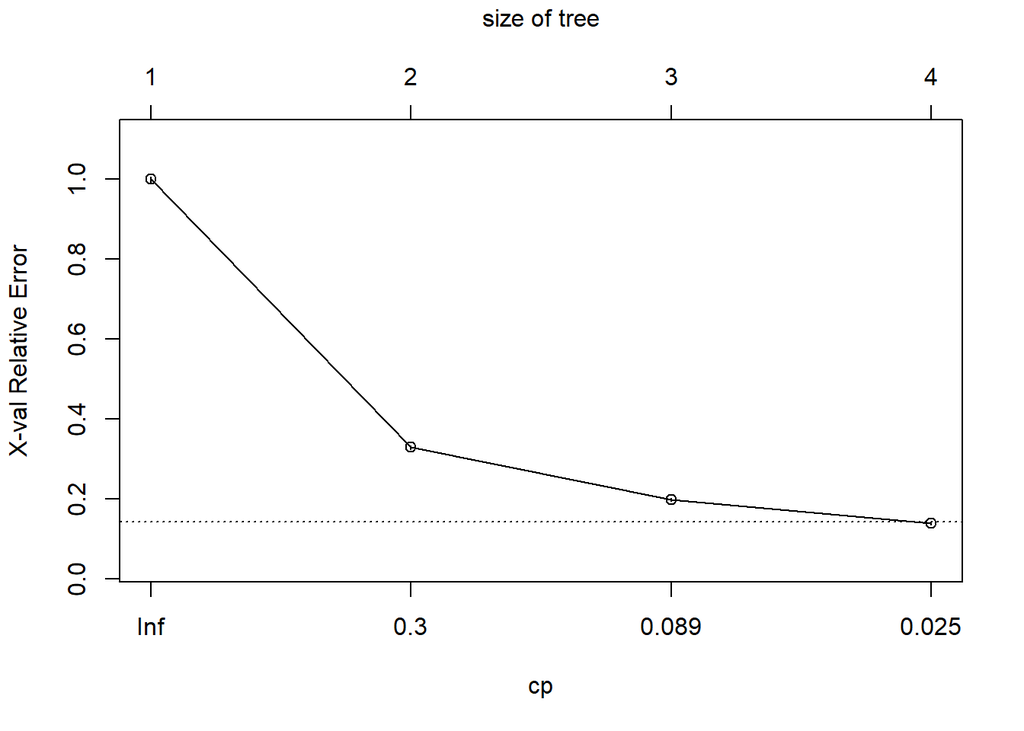

```r
plotcp(dt_model)   # Plot cross-validated error vs cp
```